# WNBA Salaries

Data sources: WNBA salaries: herhoopstats WNBA teams: espn

```r
library(tidyverse)
```

Load the data (found in Files/data on Canvas):

```r
salaries <- read_csv("data/wnba_salaries.csv")
teams <- read_csv("data/wnba_teams.csv")
```

**Get to know the data**

- how many rows? the tables have different numbers of rows! why?
- what is one row? for each table, one row is one player
- what’s in every column?

Check columns:

```r
teams %>% count(college)
```

| college | n |
| --- | --- |
| Arizona | 2 |
| Auburn | 1 |
| Baylor | 8 |
| Cal-Davis | 1 |
| California | 2 |
| Connecticut | 16 |
| Delaware | 2 |
| Duke | 4 |
| Florida Gulf Coast | 1 |
| Florida Southern | 1 |

[output cut: 52 more lines]

```r
# pretty clean, although Texas A&M has an encoding issue
teams %>% filter(is.na(college))
```

| player_name | team | number | position | height_in | weight | college | country | draft_year |
| --- | --- | --- | --- | --- | --- | --- | --- | --- |
| Rebecca Allen | Connecticut Sun | 9 | G | 74 | 162 | NA | Australia | 2015 |
| Ivana Dojkic | NA | NA | G | 71 | 154 | NA | Croatia | 2023 |
| Cayla George | Las Vegas Aces | 13 | C-F | 76 | 192 | NA | Australia | 2015 |
| Bernadett Hatar | Connecticut Sun | 44 | C | 82 | 208 | NA | Hungary | 2021 |
| Marine Johannès | New York Liberty | 23 | G | 70 | 134 | NA | France | 2019 |
| Jade Melbourne | Seattle Storm | 6 | G | 71 | 145 | NA | Australia | 2023 |
| Li Meng | Washington Mystics | 3 | G | 72 | 198 | NA | China | 2023 |
| Nikolina Milic | Minnesota Lynx | 31 | F | 75 | 181 | NA | Bosnia and Herzegovina | 2022 |
| Han Xu | New York Liberty | 21 | C | 83 | 203 | NA | China | 2019 |

```r
# looks like some international players don't have a college listed (they probably went to school overseas)
```

Practice joins:

```r
# Salaries has more rows than teams. Which players in salaries are not in teams?
# For this, use anti_join(), which gives you rows from x that don't have a match in y.
# Look at the column names that share information: `name` from salaries and `player_name` from teams:
anti_join(salaries, teams, by = c("name" = "player_name"))
```

| name | contract_amt | games | games_start | minutes | points | field_goals_made | field_goals_attempted | field_goal_pct | two_pointers_made | two_pointers_attempted | two_pointer_pct | three_pointers_made | three_pointers_attempted | three_pointer_pct | free_throws_made | free_throws_attempted | free_throw_percent | offensive_rebounds | defensive_rebounds | total_rebounds | assists | turnovers | steals | blocks | fouls |
| --- | --- | --- | --- | --- | --- | --- | --- | --- | --- | --- | --- | --- | --- | --- | --- | --- | --- | --- | --- | --- | --- | --- | --- | --- | --- |
| Isabelle Harrison | 160000 | 0 | 0 | NA | NA | NA | NA | NA | NA | NA | NA | NA | NA | NA | NA | NA | NA | NA | NA | NA | NA | NA | NA | NA | NA |
| Lou Lopez Senechal | 71300 | 0 | 0 | NA | NA | NA | NA | NA | NA | NA | NA | NA | NA | NA | NA | NA | NA | NA | NA | NA | NA | NA | NA | NA | NA |

```r
# Reverse the order to find rows in teams that are not in salaries:
anti_join(teams, salaries, by = c("player_name" = "name"))
```

| player_name | team | number | position | height_in | weight | college | country | draft_year |
| --- | --- | --- | --- | --- | --- | --- | --- | --- |
| Asia (AD) Durr | Atlanta Dream | 23 | G | 70 | 151 | Louisville | USA | 2019 |

```r
# If we want to analyze this data, what join should we use?
# An inner_join() gives us only matches (we'll lose the three players that are only in one table)
# A full_join() gives us all the rows, including those three players (this is what we chose):
full_join(salaries, teams, by = c("name" = "player_name"))
```

| name | contract_amt | games | games_start | minutes | points | field_goals_made | field_goals_attempted | field_goal_pct | two_pointers_made | two_pointers_attempted | two_pointer_pct | three_pointers_made | three_pointers_attempted | three_pointer_pct | free_throws_made | free_throws_attempted | free_throw_percent | offensive_rebounds | defensive_rebounds | total_rebounds | assists | turnovers | steals | blocks | fouls | team | number | position | height_in | … |
| --- | --- | --- | --- | --- | --- | --- | --- | --- | --- | --- | --- | --- | --- | --- | --- | --- | --- | --- | --- | --- | --- | --- | --- | --- | --- | --- | --- | --- | --- | --- |
| A'ja Wilson | 202154 | 40 | 40 | 30.7 | 22.8 | 8.4 | 15.0 | 0.557 | 8.2 | 14.3 | 0.570 | 0.2 | 0.7 | 0.310 | 5.8 | 7.2 | 0.812 | 2.1 | 7.5 | 9.5 | 1.6 | 1.6 | 1.4 | 2.2 | 2.1 | Las Vegas Aces | 22 | C | 76 | … |
| Aari McDonald | 78586 | 24 | 9 | 23.5 | 7.9 | 2.8 | 6.8 | 0.402 | 1.7 | 3.6 | 0.477 | 1.0 | 3.3 | 0.321 | 1.3 | 1.8 | 0.762 | 0.3 | 1.8 | 2.0 | 3.0 | 1.6 | 0.6 | 0.0 | 1.6 | Atlanta Dream | 2 | G | 66 | … |
| Abby Meyers | 12997 | 9 | 0 | 4.1 | 1.4 | 0.6 | 1.4 | 0.385 | 0.6 | 1.0 | 0.556 | 0.0 | 0.4 | 0.000 | 0.3 | 0.3 | 1.000 | 0.1 | 0.3 | 0.4 | 0.0 | 0.1 | 0.1 | 0.2 | 0.6 | NA | NA | G | 72 | … |
| Aerial Powers | 201984 | 20 | 0 | 9.7 | 5.2 | 1.9 | 4.6 | 0.413 | 1.6 | 3.7 | 0.438 | 0.3 | 1.0 | 0.316 | 1.1 | 1.2 | 0.917 | 0.3 | 1.5 | 1.8 | 0.8 | 0.9 | 0.2 | 0.1 | 0.3 | Minnesota Lynx | 3 | G | 71 | … |
| Alaina Coates | 20837 | 12 | 0 | 2.9 | 0.9 | 0.4 | 0.5 | 0.833 | 0.4 | 0.5 | 0.833 | 0.0 | 0.0 | NA | 0.1 | 0.3 | 0.250 | 0.2 | 0.7 | 0.8 | 0.0 | 0.6 | 0.3 | 0.0 | 0.8 | Las Vegas Aces | 81 | C | 76 | … |
| Alanna Smith | 100000 | 38 | 35 | 26.5 | 9.2 | 3.5 | 7.0 | 0.498 | 2.7 | 4.3 | 0.626 | 0.8 | 2.7 | 0.294 | 1.4 | 2.1 | 0.679 | 1.8 | 4.7 | 6.6 | 1.8 | 1.5 | 1.3 | 1.3 | 3.1 | Chicago Sky | 8 | F | 76 | … |
| Aliyah Boston | 74305 | 40 | 40 | 31.2 | 14.5 | 5.8 | 10.1 | 0.578 | 5.7 | 9.8 | 0.583 | 0.1 | 0.3 | 0.400 | 2.7 | 3.6 | 0.745 | 3.1 | 5.3 | 8.4 | 2.2 | 1.9 | 1.3 | 1.3 | 3.1 | Indiana Fever | 7 | F-C | 77 | … |
| Allisha Gray | 194600 | 38 | 38 | 32.7 | 17.1 | 5.8 | 12.4 | 0.465 | 4.7 | 9.3 | 0.501 | 1.1 | 3.1 | 0.356 | 4.4 | 5.4 | 0.824 | 1.2 | 3.7 | 4.9 | 3.1 | 1.9 | 1.1 | 0.4 | 2.6 | Atlanta Dream | 15 | G | 72 | … |
| Alysha Clark | 110000 | 39 | 1 | 22.5 | 6.7 | 2.3 | 5.3 | 0.444 | 1.0 | 1.9 | 0.548 | 1.3 | 3.4 | 0.386 | 0.7 | 0.8 | 0.818 | 0.5 | 2.9 | 3.4 | 1.1 | 0.7 | 0.6 | 0.2 | 2.2 | Las Vegas Aces | 7 | F | 71 | … |
| Alyssa Thomas | 212000 | 40 | 40 | 36.1 | 15.5 | 6.1 | 12.8 | 0.474 | 6.1 | 12.8 | 0.476 | 0.0 | 0.1 | 0.000 | 3.3 | 4.7 | 0.715 | 2.0 | 7.9 | 9.9 | 7.9 | 3.4 | 1.8 | 0.5 | 2.7 | Connecticut Sun | 25 | F | 74 | … |

[output cut: 154 more lines]

```r
# Note that the new table has 34 columns, all the columns from both tables (minus the duplicative `player_name` from teams).

# We can turn this joined data into a new variable to analyze:
full_table <- full_join(salaries, teams, by = c("name" = "player_name"))

# You can also incorporate joins within the workflow of analysis.
# In the code below we filter salaries for only those players who make at least 50% of their shots, and then join the data to teams, to find out which team has the most high-percentage shooters:
salaries %>%
  filter(field_goal_pct > .5) %>%
  left_join(teams, by = c("name" = "player_name")) %>%
  count(team) %>%
  arrange(desc(n))
```

| team | n |
| --- | --- |
| Chicago Sky | 3 |
| Dallas Wings | 3 |
| Las Vegas Aces | 3 |
| Phoenix Mercury | 3 |
| Seattle Storm | 3 |
| Connecticut Sun | 2 |
| New York Liberty | 2 |
| Atlanta Dream | 1 |
| Indiana Fever | 1 |
| Los Angeles Sparks | 1 |

[output cut: 2 more lines]

**REVERSE HOMEWORK! YOU ASK THE QUESTIONS AND I’LL ANSWER THEM.**  
Questions we asked of the data:

1. How do the tallest and shortest players compare? Specifically, games started (an indication of whether you’re a good player). **LIZ: When you’re comparing “tall” players and “short” players, keep in mind that short > tall is a continuum, these are not buckets. So we either need to create buckets, or we can plot two continuous variables and visually look to see if there are any obvious connections.**

```r
# 1: create buckets to compare
# what is the average height of a wnba player? we can use that as a dividing point. we should check it against the median, though, which might be a better middle
teams %>% summarise(avg_height = mean(height_in),
                    med_height = median(height_in))
```

| avg_height | med_height |
| --- | --- |
| 72.68519 | 73 |

```r
# almost the same, so we'll go with 73 inches.

# 2: look at games_started for each group (above and below average height); let's add in average field goal percentage, and 3-point percentage for a more well-rounded comparison. These are fields from salaries, so we'll do an inner_join (excluding players who aren't in both tables):
teams %>%
  inner_join(salaries, by = c("player_name" = "name")) %>%
  filter(height_in < 73) %>%
  summarise(n = n(), # how many players overall
            games_start = mean(games_start), # average games started
            mean_fgp = mean(field_goal_pct, na.rm=T), # be sure to exclude NAs
            mean_3pt = mean(three_pointer_pct, na.rm=T)) # be sure to exclude NAs
```

| n | games_start | mean_fgp | mean_3pt |
| --- | --- | --- | --- |
| 75 | 15.54667 | 0.3860833 | 0.3090423 |

```r
teams %>%
  inner_join(salaries, by = c("player_name" = "name")) %>%
  filter(height_in >= 73) %>%
  summarise(n = n(),
            games_start = mean(games_start),
            mean_fgp = mean(field_goal_pct, na.rm=T),
            mean_3pt = mean(three_pointer_pct, na.rm=T))
```

| n | games_start | mean_fgp | mean_3pt |
| --- | --- | --- | --- |
| 86 | 14.34884 | 0.4450494 | 0.2580986 |

```r
### So, in terms of games started, it's not much different, about one game apart. Not surprisingly, "shorter" players have a better 3-point percentage (they tend to be out on the arc and not under the basket) but "taller" players (who tend to play in the paint and take higher percentage shots) have a higher field goal percentage overall.
```

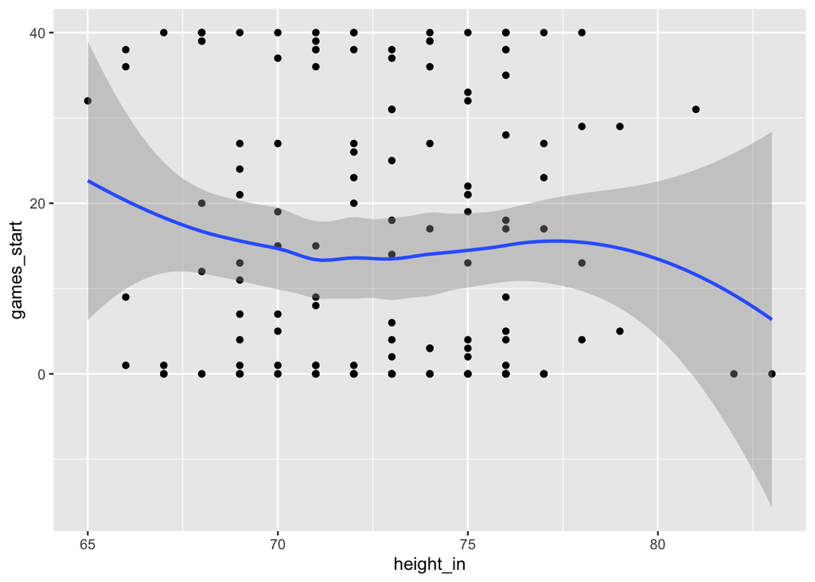

```r
###LIZ: now let's look at a scatterplot of two continuous variables, height and ____ (we'll sub in games_start and field_goal_pct separately):
teams %>%
  inner_join(salaries, by = c("player_name" = "name")) %>%
  ggplot(aes(x=height_in, y=games_start)) +
  geom_point() +
  geom_smooth()
```

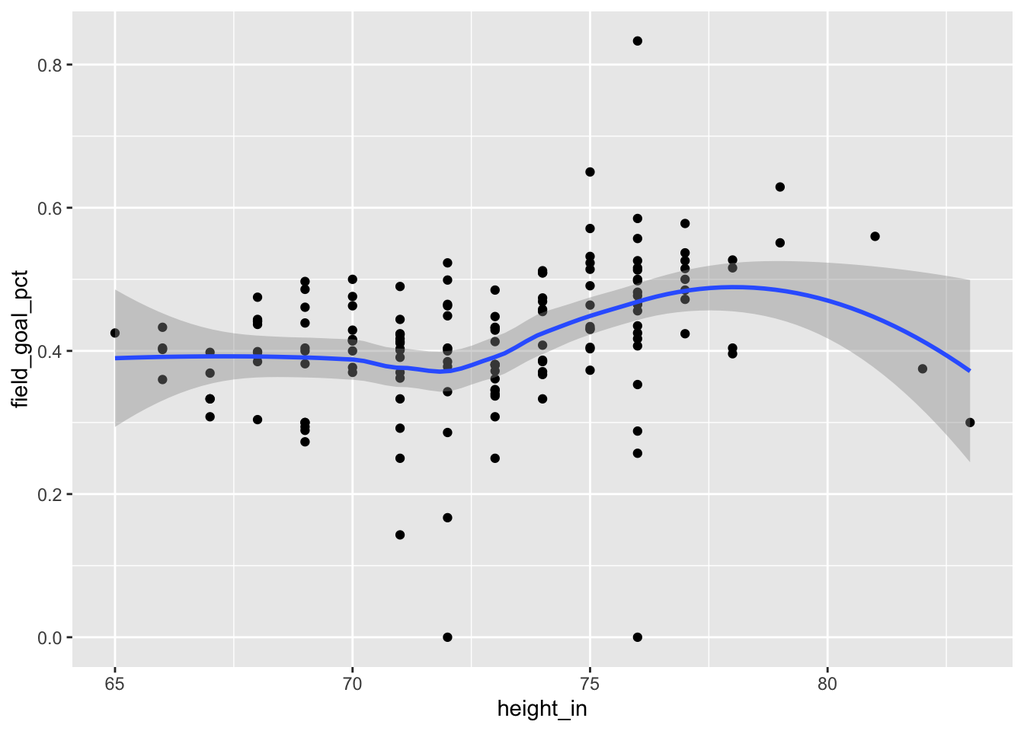

```r
# no discernible relationship here

teams %>%
  inner_join(salaries, by = c("player_name" = "name")) %>%
  ggplot(aes(x=height_in, y=field_goal_pct)) +
  geom_point() +
  geom_smooth()
```

```r
# maybe a slight relationship - increase in fgp as height reaches the average of about 73.

###LIZ: keep in mind that to talk about "correlation" we'd have to get more data, multiple years, to really look for a relationship between height and performance, and do a more robust analysis. This is just a gut check graph.

###Conclusion: no real indication that taller players are better players.
```

2. Who had the best/worst assist to turnover ratio (a common stat for guards)? **LIZ: a ratio is usually expressed in 1:X (a common example is teacher to student ratio in public schools; 1:15 is one teacher for every fifteen students). In this stat, “good” is defined as more assists than turnovers. A 1:1 ration would be one turnover for every assist. Ideally a player wants more assists than turnovers: assists/turnovers > 1. We’ll start by ignoring players that don’t have any assists**

```r
salaries %>%
  filter(assists >= 1) %>%
  mutate(assist_turnover_ratio = assists/turnovers) %>%
  select(name, assist_turnover_ratio) %>%
  arrange(desc(assist_turnover_ratio))
```

| name | assist_turnover_ratio |
| --- | --- |
| Veronica Burton | 5.5000000 |
| Odyssey Sims | 3.6666667 |
| Lindsay Allen | 3.4615385 |
| Shey Peddy | 3.0000000 |
| Courtney Vandersloot | 3.0000000 |
| Chelsea Gray | 2.9200000 |
| Crystal Dangerfield | 2.5833333 |
| Danielle Robinson | 2.5384615 |
| Breanna Stewart | 2.5333333 |
| Courtney Williams | 2.5200000 |

[output cut: 84 more lines]

```r
###LIZ: Veronica Burton had 5.5 assists per 1 turnover, which is a good ratio. Conversely, NaLyssa Smith had twice as many turnovers as assists (.5 assists per 1 turnover). She's a young post player, so that's not too surprising. It would be more interesting to compare guards (who play a bigger role in passing) who had a assist/turnover ratio < 1. For that we need position, which is in the teams table:

salaries %>%
  inner_join(teams, by=c("name"="player_name")) %>%
  filter(assists >= 1 & position=="G") %>%
  mutate(assist_turnover_ratio = assists/turnovers) %>%
  select(name, assist_turnover_ratio) %>%
  arrange(desc(assist_turnover_ratio))
```

| name | assist_turnover_ratio |
| --- | --- |
| Veronica Burton | 5.500000 |
| Odyssey Sims | 3.666667 |
| Lindsay Allen | 3.461538 |
| Shey Peddy | 3.000000 |
| Courtney Vandersloot | 3.000000 |
| Chelsea Gray | 2.920000 |
| Crystal Dangerfield | 2.583333 |
| Danielle Robinson | 2.538462 |
| Courtney Williams | 2.520000 |
| Shatori Walker-Kimbrough | 2.428571 |

[output cut: 43 more lines]